# R을 활용한 Horse Colic 데이터를 통한 통계적 분석

by seung hoon

2020 3 5

# R을 활용한 Horse Colic 데이터를 통한 통계적 분석

## 1. 데이터 준비

### 1-1. 데이터 설명

이용한 데이터는 Kaggle 웹사이트에서 얻은 Horse Colic Dataset이다. (원 데이터의 출처는 UCI Machine Learning Database 이다.) Horse Colic Dataset은 말의 여러가지 의학적 관측값과 생존여 부에 대한 데이터를 가지고 있다.

Horse Colic Dataset은 28 개의 변수를 가지고 있다. 하지만 이 모든 변수를 전부 활용할 수는 없 었다.변수 설명에 시작하기에 앞서 먼저 본 데이터에 대해 간략한 형태를 먼저 보고, 분석에 적합 한 변수를 추리고자 한다.  
먼저 Horse Colic Dataset은 각 변수에서 발견되는 결측치의 비율이 많은 편이었다. 각 변수에 대 한 결측치의 비율은 다음과 같다.

```r
#데이터 불러오기
library(tidyverse)
data = read_csv("C:/Users/SeungSeungSsi/Desktop/기말프로젝트/Horse/horse-colic/horse.csv")
apply(data, 2, function(col)sum(is.na(col))/length(col))
```

```
##               surgery                   age       hospital_number
##            0.00000000            0.00000000            0.00000000
##           rectal_temp                 pulse      respiratory_rate
##            0.20066890            0.08026756            0.19397993
##   temp_of_extremities      peripheral_pulse       mucous_membrane
##            0.18729097            0.23076923            0.15719064
## capillary_refill_time                  pain           peristalsis
##            0.10702341            0.18394649            0.14715719
##  abdominal_distention      nasogastric_tube    nasogastric_reflux
##            0.18729097            0.34782609            0.35451505
## nasogastric_reflux_ph     rectal_exam_feces               abdomen
##            0.82274247            0.34113712            0.39464883
##    packed_cell_volume         total_protein     abdomo_appearance
##            0.09698997            0.11036789            0.55183946
##        abdomo_protein               outcome       surgical_lesion
##            0.66220736            0.00000000            0.00000000
##              lesion_1              lesion_2              lesion_3
##            0.00000000            0.00000000            0.00000000
##               cp_data
##            0.00000000
```

```r
view(data)
```

surgery, age, rectal_temp, pulse, respiratory_rate, temp_of_extremities, pheripheral_pulse, mucous_membrane, capillary_refill_time, pain, peristalsis, packed_cell_volume, outcome, surgical_lesion

다음은 분석에 사용한 변수에 대한 설명과, 그에 대한 분포를 그린 barplot과 boxplot이다.

#### Outcome(생존여부) 1 = 생존 2 = 사망 3 = 안락사

생존한 사례가 가장 많았으며, 안락사 한 사례가 가장 적었다.

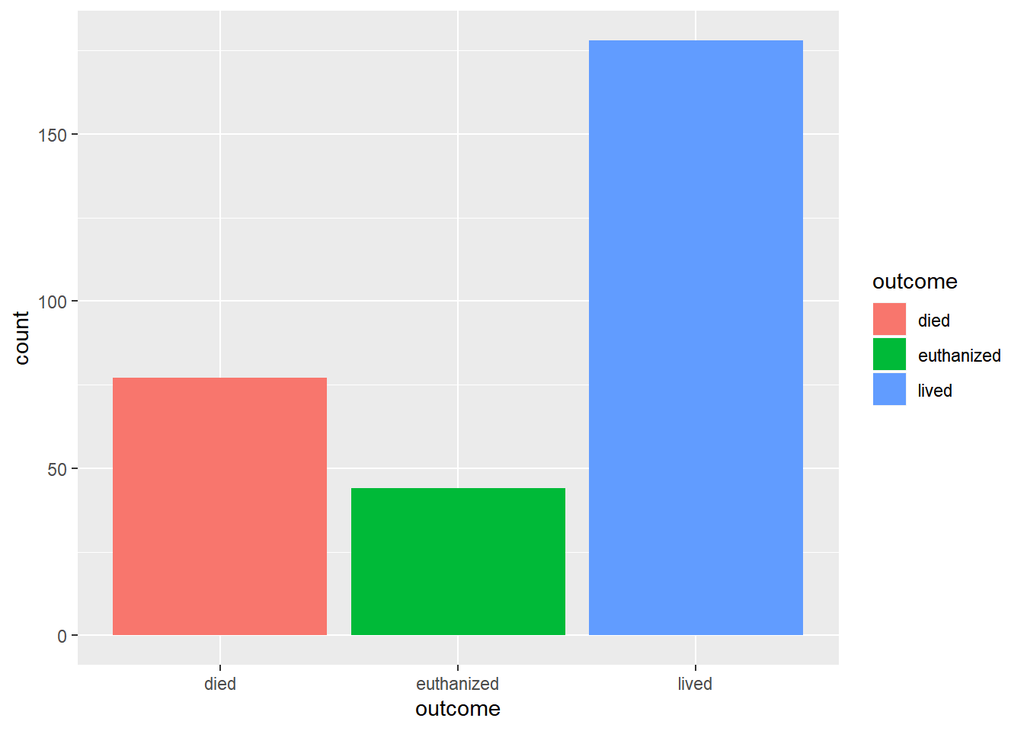

```r
ggplot(data = data)+
  geom_bar(mapping = aes(x=outcome , fill= outcome))
```

#### Surgery(수술유무) 1 = 수술을 받음 2 = 수술을 받지 않음

수술을 받은 경우가 받지 않은 경우보다 수술을 받은 사례가 더 많았다.

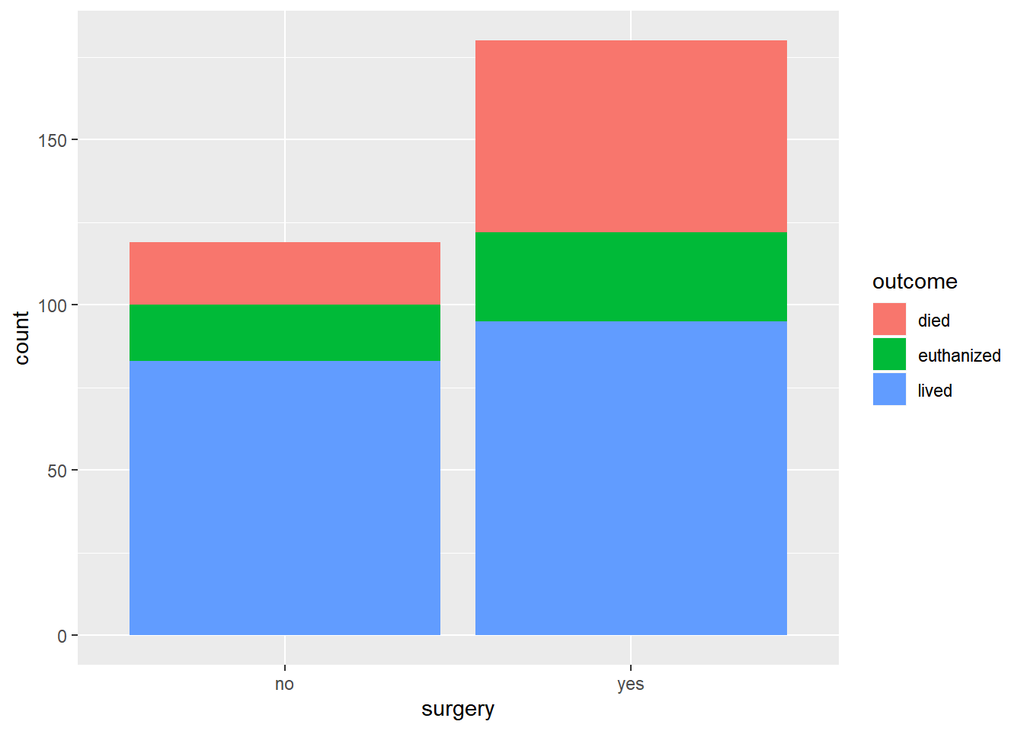

```r
ggplot(data = data)+
  geom_bar(mapping = aes(x= surgery, fill= outcome))
```

#### Age(나이) 1 = 성년 2 = 생후 6개월 미만

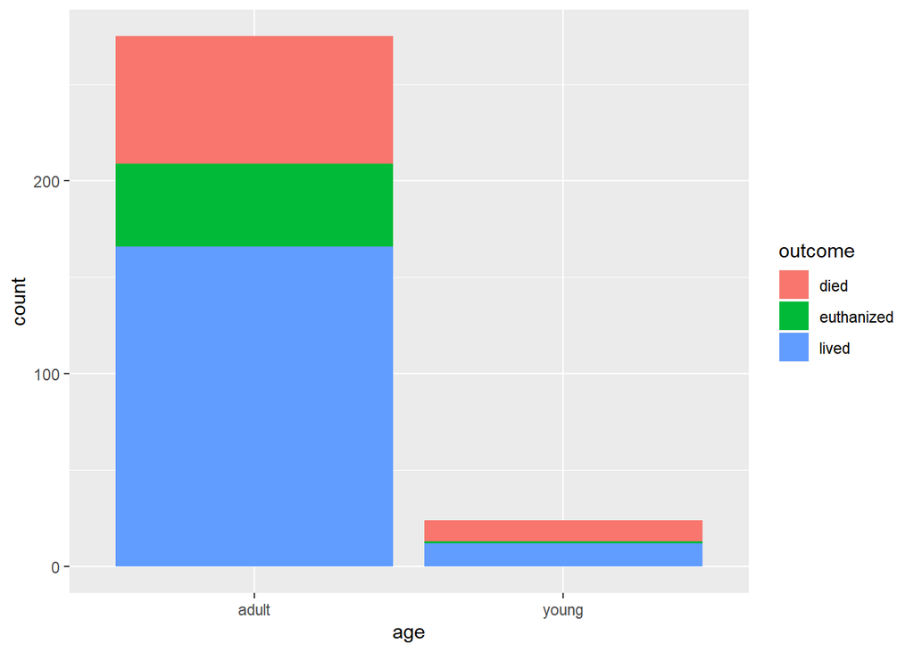

```r
ggplot(data = data)+
  geom_bar(mapping = aes(x=age, fill= outcome))
```

#### Rectal_temp(직장의 온도)

- 섭씨로 기록되어있다. (연속형)
- 감염이 있을 때 온도가 높아 질 수 있으 며, 후에 쇼크가 올 시에 온도가 낮아질 수 있다.
- 정상에서의 평균은 37.8 이다.

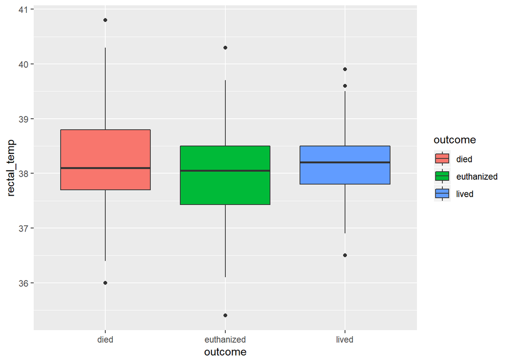

```r
ggplot(data = data)+
  geom_boxplot(mapping = aes(x=outcome, y=rectal_temp, fill= outcome))
```

#### Pulse(맥박)

- 분당 심박수이다.(연속형)
- 성년 말은 30~40이 정상범주이다.
- 정상범주보다 낮은 경우는 드물지마 경 주마인 경우, 또는 외과적상해를 입은 경 우에는 심박수가 올라갈 수도 있다.
- 생존한 경우의 중위값이 죽거나 안락사 한 경우보다 월등히 낮다는 것을 확인했다.

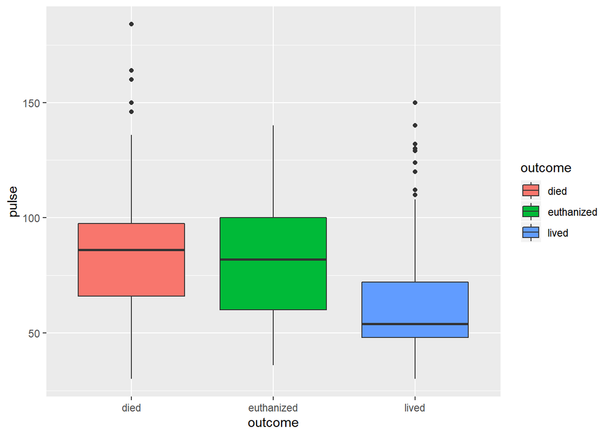

```r
ggplot(data = data)+
  geom_boxplot(mapping = aes(x=outcome, y=pulse, fill= outcome))
```

#### Respiratory_rate(호흡률)

- 연속형 변수이다.
- 8에서 10이 정상적 범주이다.
- 변동이 심하기 때문에 의미 있는 변수인 지는 확실치 않다고 명시 되어있다.

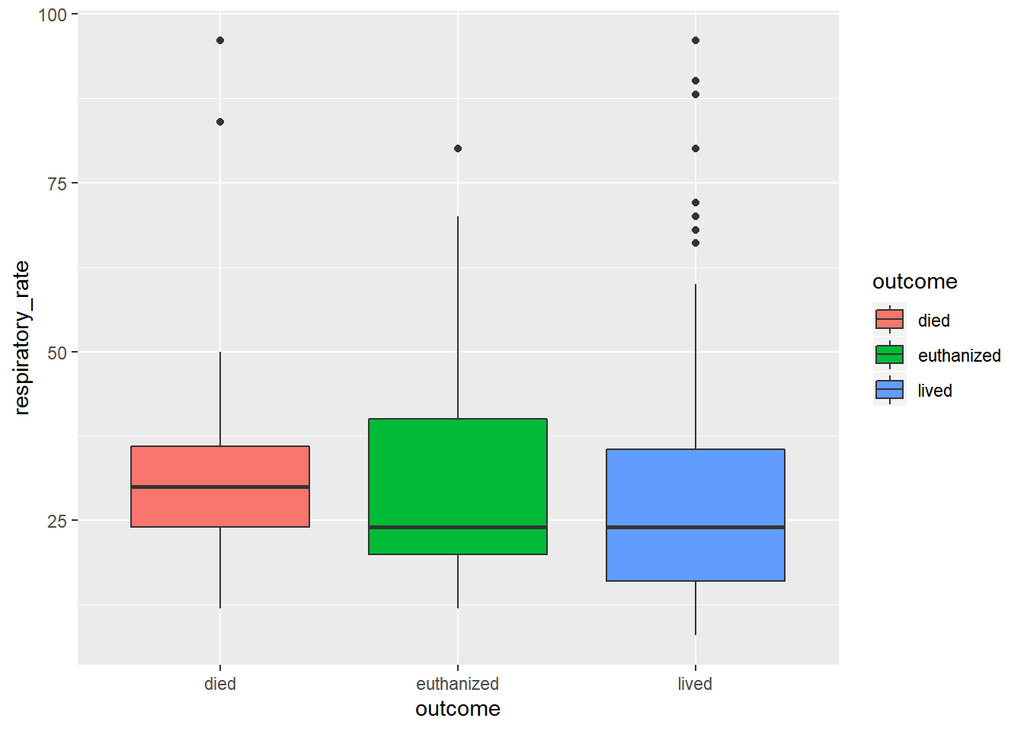

```r
ggplot(data = data)+
  geom_boxplot(mapping = aes(y=respiratory_rate, x= outcome, fill=outcome))
```

#### Temp_of_extremities(사지의 온도) 1 = Normal 2 = Warm 3 = Cool 4 = Cold

- 주관적으로 혈류를 확인하는 변수이다.
- 차갑다면 쇼크인 경향인 경향이 있다.

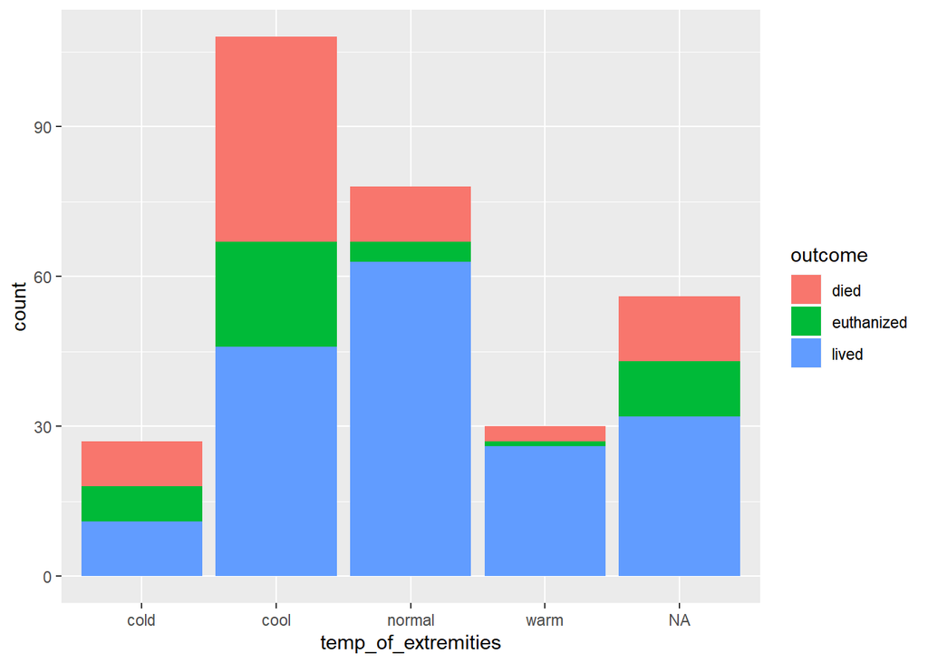

```r
ggplot(data = data)+
  geom_bar(mapping = aes(x=temp_of_extremities, fill= outcome))
```

#### Peripheral_pulse(주변 맥박) 1 = normal 2 = increased 3 = reduced 4 = absent

Normal이거나 increased 되었을때 혈류 흐 름이 적절수준이라고 평가 되며, 아닐시에 는 혈류가 좋지 않다는 것을 나타낸다.

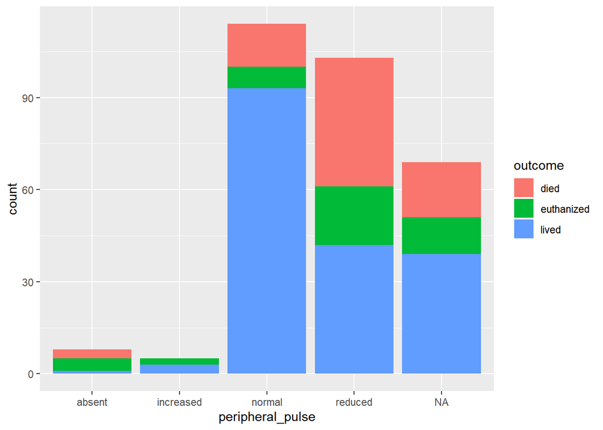

```r
ggplot(data = data)+
  geom_bar(mapping = aes(x=peripheral_pulse , fill= outcome))
```

#### Mucous_membrane(점막) 1 = normal pink 2 = bright pink 3 = pale pink 4 = pale cyanotic 5 = bright red / injected 6 = dark cyanotic - 주관적으로 표기한 색이다. - 1과 2는 정상 또는 조금 증가한 혈류를 암시할 수 있다.

- 3은 이른 쇼크에서 나타날 수 있다.
- 4 와 6 은 혈류가 매우 좋지 않음을 나타낸다.
- 5 는 패혈증을 나타낼 수 있다.

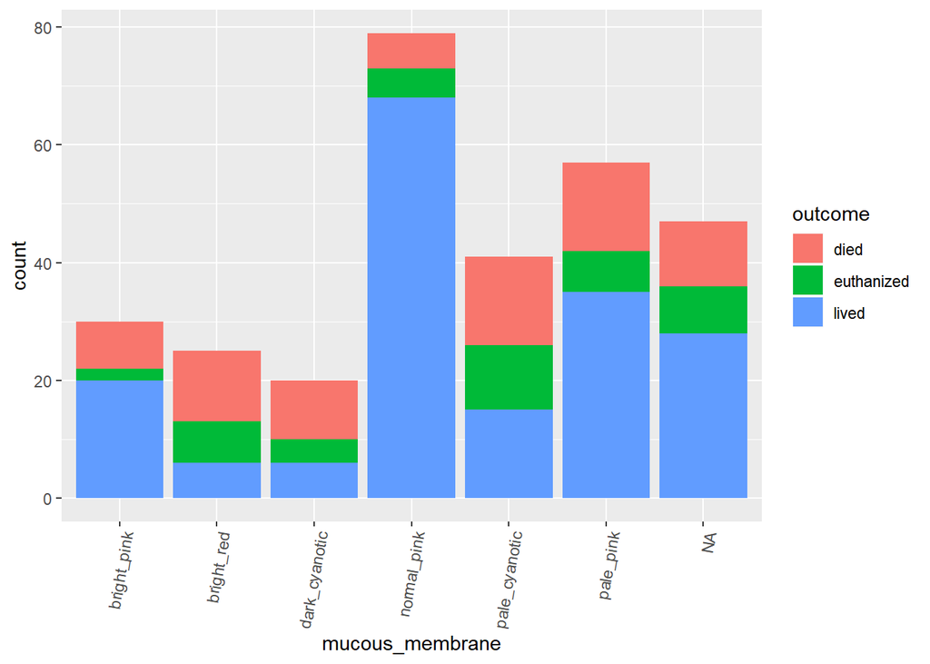

```r
ggplot(data = data)+
  geom_bar(mapping = aes(x=mucous_membrane , fill= outcome ))+
  theme(axis.text.x = element_text(angle = 80, hjust = 1))
```

#### Capillary_refill_time(모세혈관 충전 시간) 1 = 3초 이하 2 = 3초 이상

-의학적으로 표기된 변수이다.  
- 충전시간이 길면 혈류가 좋지 않다는 것을 나타낸다.

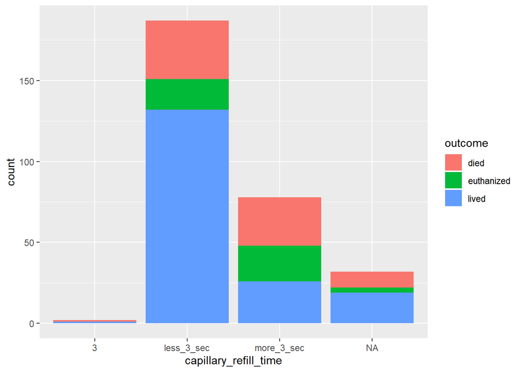

```r
ggplot(data = data)+
  geom_bar(mapping = aes(x=capillary_refill_time, fill= outcome))
```

#### Pain(고통) 1 = alert, no pain 2 = depressed 3 = intermittent mild pain 4 = intermittent severe pain 5 = continuous severe pain

- 주관적 판단에 의해 작성된 항목이다.
- 고통스러울수록 수술을 받는 경우가 많다.
- 초기 조치에 따라 고통이 경감 될 수도 있다.

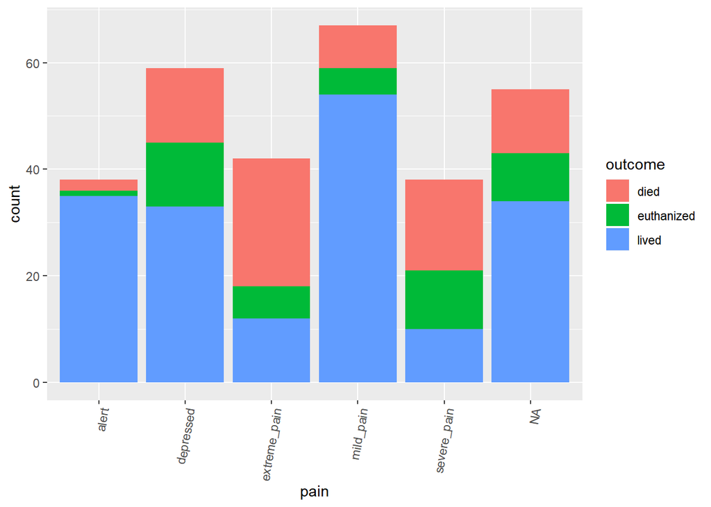

```r
ggplot(data = data)+
  geom_bar(mapping = aes(x=pain , fill= outcome))+
  theme(axis.text.x = element_text(angle = 80, hjust = 1))
```

#### Peristalsis(연동운동) 1 = hypermotile(과운동성) 2 = normal(정상) 3 = hypomotile(저운동성) 4 = absent(부재)

-내장활동을 나타내는 지표이다. -내장이 부 풀면 독소가 있다는 것을 나타내며, 활동도 줄어들게 된다.

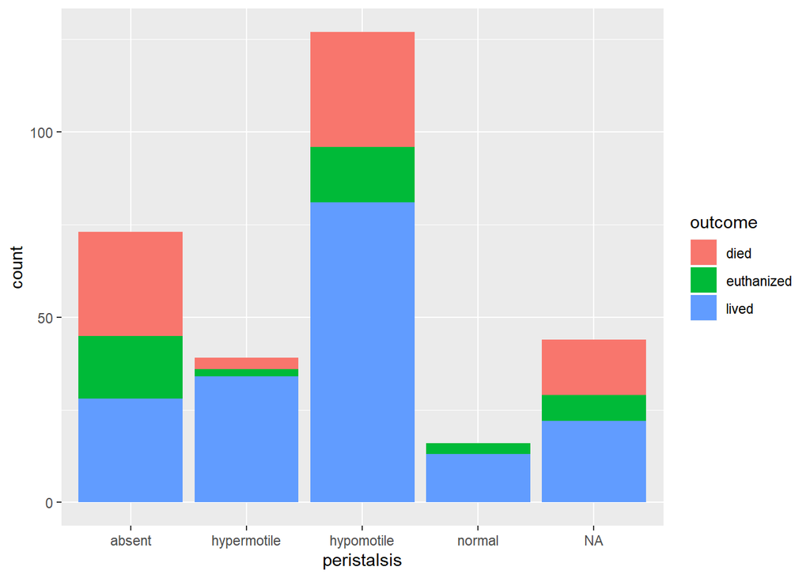

```r
ggplot(data = data)+
  geom_bar(mapping = aes(x=peristalsis , fill= outcome))
```

#### Packed_cell_volume

- 연속형 변수이며 혈액속 적혈구의 수를 나타낸다.
- 30~50 사이가 보통이며, 면역 반응이 제대로 일어나지 않거나 탈수 증세가 나타나면 그 정도가 높아질 수 있다.  
  -생존한 경우 다른 경우보다 그 정도가 훨 씬 낮았다.

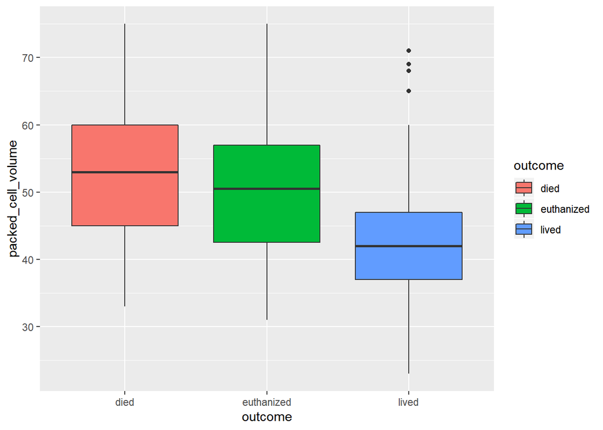

```r
ggplot(data = data)+
  geom_boxplot(mapping = aes(x=outcome,y=packed_cell_volume   , fill= outcome))
```

#### Surgical_lesion(외과적 병변 여부) 1 = Yes 2 = No

-외과적 병변이었을 때 사망한 경우가 더 많았음을 알 수 있었다

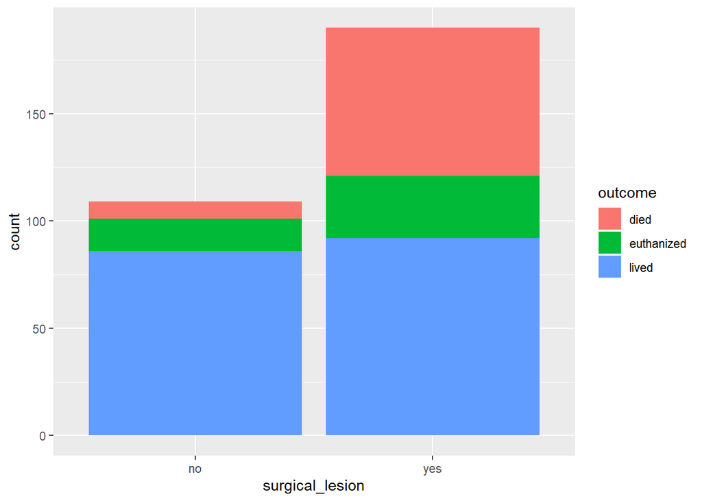

```r
ggplot(data = data)+
  geom_bar(mapping = aes(x=surgical_lesion , fill= outcome))
```

다음은 전처리를 위한 코드이다.

-범주형 숫자로 바꾸기(후에 사용할 패키지 이용을 위해서)

```r
library(tidyr)
library(tidyverse)


col <-colnames(data)
data <- data.frame(matrix(unlist(data), ncol=28, byrow=F),stringsAsFactors=FALSE)
colnames(data) <- col
```

쓰지 않기로 한 변수는 버리기

```r
drops <- c("hospital_number","abdomo_appearance","abdomo_protein","nasogastric_reflux_ph","nasogastric_tube","nasogastric_reflux","rectal_exam_feces","abdominal_distention","total_protein","abdomen","lesion_1","lesion_2","lesion_3","cp_data")
data = data[ , !(names(data) %in% drops)]
data
```

[output not shown]

[output cut: 885 more lines]